# My First R Notebook

This is an R Notebook that shows you how to create an R Notebook!

I love R Notebooks because they can be used to generate word documents or html files from your code. So you can create your code and send it to anyone–even people that don’t have R.

First, open up RStudio. It should look something like this:

[figure not shown]

Your background might be white. If you’d like to change it, go to RStudio–>Preferences–>Appearance. (If you’re on a mac. If you’re on a PC, google is your friend!)

The ‘console’ takes up most of the space on the left side of the screen. The console is a place where you can enter R commands one line at a time. If you’d like, you run your analyses this way: one way line at a time.

Instead of the console, you could create a script file. The script file would then take up most of the space on the left side of the screen. A script file is kinda like an SPSS syntax file. It’s a list of commands for R. If you’d like, you could run your analyses that way–type your commands into the script file and then run them. What’s good about script files is the same as what’s good about SPSS syntax files–you have a record of the analyses you did.

To create a new R Notebook file, go to File –> New File –> R Notebook

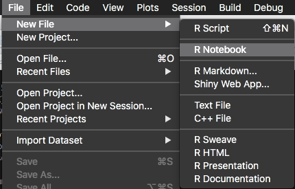

Now RStudio should look something like this for you:

[figure not shown]

Now the R Notebook takes up most the space on the left side of the screen.

Take a look at the right side of the screen. There are two windows there. The top window tells you information about R ‘environment.’

The bottom window has a number of tabs. This is a useful place to quickly access your file directory, the packages that can be loaded, and also output. I like to see my output side by side with my code, so let’s enlarge the bottom window so it takes up the entire right side of the screen. Either you can drag it up or press the ‘maximize’ button in the corner.

[figure not shown]

Now you’re RStudio should look something like this.

I want to show you something cool about R Notebooks. You can press the ‘Preview’ button anytime and a preview of your output document will appear in the ‘Viewer’ on the right side of the screen. The preview button can be found on the left side of the screen above your R Notebook.

Try pressing it now. First you will be asked to save your Notebook. If you press it again, after saving, your screen should look something like this:

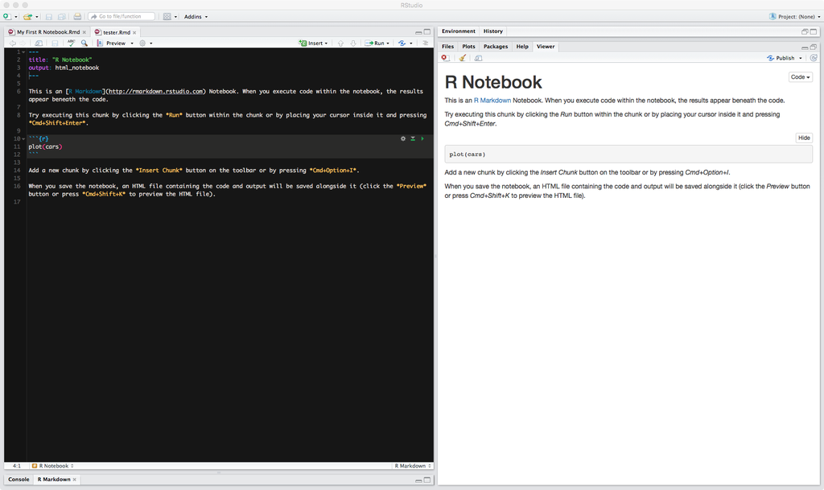

Another great thing about the ‘Preview’ button is everytime you press it, not only do you get a preview of your output document, it also automatically saves your file.

First, the header.

This basic header contains two pieces of information. The title of the notebook and the type of output file. You can change both just by typing.

Try it out now. Change the title to “My First R Notebook” and then press preview. You should see the title of your output doc has changed now.

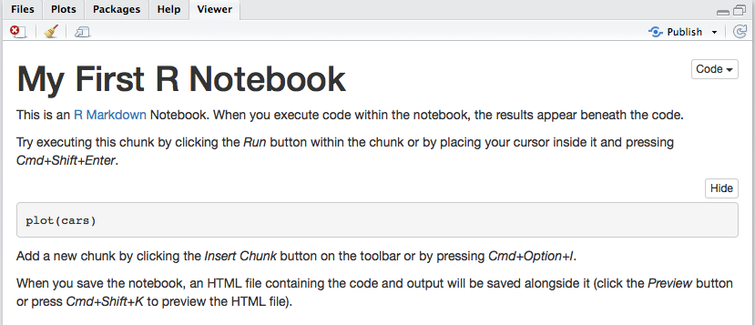

You can change the output type the same way. Just type the output style you’d like! Here is a list of possible output types. Feel free to try them out. Each one shoud produce a new document of that type in the same folder you saved your R Notebook file.

- **html_document**
  - regular html page, not an R Notebook html page. An R Notebook html page is a self-contained document that includes all output.
- **pdf_document**
  - a pdf
- **word_document**
  - a word document–this is useful for writing manuscripts. Imagine your analysis is automatically exported to word! If you make a small change, no problem–it’s already in the manuscript!
- **odt_document**
  - Open Document Text file
- **rtf_document**
  - Rich Text format
- **md_document**
  - markdown document
- **github_document**
  - Github compatible markdown document
- **ioslides_presentation**
  - ioslides html presentation
- **slidy_presentation**
  - slidy html slides presentation
- **beamer_presentation**
  - beamer pdf slides

However, I recommend sticking with ‘html_notebook’.

Now let’s take a look at the code below the header.

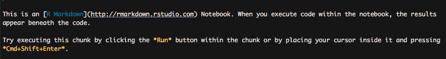

Markdown example

You’ll notice it’s mostly plain text with a few weird brackets and asterisks.

This plain text is written according to the rules of ‘Markdown.’ You can download a ‘cheatsheet’ with all the rules of ‘Markdown’ [here](https://www.rstudio.com/wp-content/uploads/2016/03/rmarkdown-cheatsheet-2.0.pdf)

Importantly, you can italicize text by surrounding it with asterisks like this: *italics*

You can bold text by surrounding it with double asterisks like this: **bold**

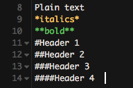

One thing to keep in mind: When you want to start a new line, add two spaces to the end of the previous line. You can’t just press enter and start a line.

Try writing some text yourself and then pressing the preview button to see what it looks like.

Ok, let’s look at the next section of code:

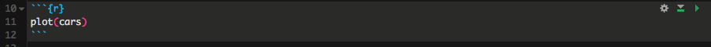

This is a code chunk. It starts with three ticks (above the tab key. NOT an apostrophe). It ends with three ticks. Inside the curly brackets is the letter r. That tells RStudio that this is a chunk of R code. That might seem obvious but you can actually put in lots of different code chunks here. You can also add Bash, Python, Rcpp, SQL, and Stan code chunks.

To add a code chunk. Press the insert button in the menubar and then select ‘R’.

Let’s write and execute your first R code!

Type the following into a new R chunk.

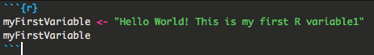

First we assign the value “Hellow World! This is my first R variable” to the variable “myFirstVariable”. Then we told RStudio to print the value of that variable.  
Press Preview and see your code in action. And that’s the basics of R Notebooks! You can do a lot just with Markdown without even writing any code in R!